# Proyecto 2

## Data Science, sección 40

## Grupo 1

Javier Alejandro Ovalle Chiquín, 22103  
José Ángel Morales Farfan, 22689  
Ricardo Josué Morales Contreras, 22289  
Karen Daniela Pineda Ventura 231132

https://github.com/Saiyan-Javi/Proyecto2DS

# Predicción de calificaciones de resúmenes (content & wording)

### Situación problemática

Los estudiantes realizan resúmenes en respuesta a una consigna, luego evaluadores puntúan cada resumen en dos factores: content (Si el resumen cubre lo solicitado) y wording (calidad de la redacción). Evaluar manualmente esto es costoso, lento y potencialmente inconsistente. Por lo que, automatizar la evaluación con modelos de PLN puede permitir retroalimentación a escala, detectar rápido resúmenes que necesiten intervención y homogeneizar criterios.

### Problema científico

Construir modelos de Procesamiento del Lenguaje Natural que, a partir del texto del resumen y del enunciado del prompt, predigan dos puntuaciones continuas (content y wording) de forma que se reduzca la discrepancia con respecto a las evaluaciones realizadas manualmente.

### Objetivos

Objetivo general

- Diseñar, implementar y evaluar un pipeline de PLN que prediga las puntuaciones content y wording de resúmenes estudiantiles con una evaluación cuantitativa reproducible (RMSE, correlaciones).

## Descripción de los datos

Variables principales

- student_summary: texto escrito por estudiantes
- prompt: enunciado al que responde el resumen
- content: puntuación otorgada al contenido
- wording: puntuación de la redacción

## Investigación preliminar

**Técnicas comunes para detección de patrones de texto**

**El preprocesamiento de Lenguaje Natural (PLN)** busca extraer conocimiento útil a partir de textos. En problemas como el de la competencia, el objetivo es detectar patrones en los resúmenes escritos por estudiantes que permitan estimar automáticamente la calidad de su contenido y redacción.

Entre las técnicas están:

Preprocesamiento de texto Antes de aplicar cualquier modelo, es necesario transformar el texto original para que sea más manejable:

- Normalización: pasar todo a minúsculas, eliminar signos de puntuación, URLs y caracteres especiales. Esto disminuye el ruido y hace más consistentes los datos.
- Tokenización: dividir el texto en unidades (tokens), que suelen ser palabras o subpalabras. Ejemplo: "The boy runs fast" = ["the", "boy", "runs", "fast"].
- Stopwords removal: eliminación de palabras vacías (the, and, is), que no aportan tanta información
- Lematización/Stemming: reducir palabras a su forma base ("running" = "run"). Permite agrupar variaciones morfológicas
- Correción de valores faltantes y outliers: textos muy cortos, vacíos o muy alrgos deben analizarse aparte

**Representación vectorial del texto**

El texto debe representarse numéricamente para que un modelo pueda procesarlo.

**Bolsa de palabras (Bag of words):** Cada documento es representado como un vector de frecuencias de palabras, ignorando el orden. Es simple y útil para detectar patrones de vocabulario físico.

**TF-IDF (Term Frecuency - Inverse Document Frecuency):** Pondera palabras según su frecuencia en un documento, penaliza las que son muy frecuentes, lo cual permite detectar palabras clave más relevantes para diferenciar textos.

**N-gramas:** Considera secuencias de palabras (bigramas, trigramas). Esto captura patrones de estilo y frases típicas de resúmenes.

**Embeddings semánticos:**

- Word2Vec, Glove, FastText, representan palabras en vectores densos que capturan similitud semántica ("dog" y "puppy").
- Embeddings contextuales (Transformers como BERT, RoBERTa, DistilBERT) capturan el significado de cada palabra en función de su contexto, lo que permite representar mejor la semántica de frases completas.

Patrones estilísticos y estructurales Se pueden usar métricas como:

- Longitud del texto: cantidad de caracteres o palabras
- Riqueza léxica: proporción de palabras únicas frente al total
- Medidas de legibilidad: índices como Flesh-Kincaid, que miden la complejidad sintáctica
- Distribución de puntuación y longitud de oraciones: redacción más clara suele usar estructuras más balanceadas

**Modelos para detección de patrones**

Regresión lineal y Ridge/Lasso: adecuados como modelos base para datos vectorizados (TF-IDF).

Árboles de decisión y ensambles (Random Forest, XGBoost, LightGBM): capturan patrones no lineales en los features.

Redes neuronales: CNN y RNN, detectan secuencias recurrentes en textos.

Transformers (BERT, RoBERTa, GPT, etc): de última generación, capaces de capturar relaciones complejas y contexto profundo, especialmente efectivos evaluación de calidad de texto.

**Evaluación de patrones**

Métricas cuantitativas: RMSE (Root Mean Squared Error), MAE (Mean Absolute Error) y correlaciones estadísticas.

Validación cruzada estratificada por prompt: asegura que el modelo no se sobreajuste, ya que los resúmenes son de temas distintos.

```python
# Carga y unión
import pandas as pd
from pathlib import Path

DATA_DIR = Path(".")
summaries = pd.read_csv(DATA_DIR / "summaries_train.csv")
prompts = pd.read_csv(DATA_DIR / "prompts_train.csv")

assert set(['student_id','prompt_id','text','content','wording']).issubset(summaries.columns)
assert set(['prompt_id','prompt_question','prompt_title','prompt_text']).issubset(prompts.columns)

df = summaries.merge(prompts, on='prompt_id', how='left')
df.head()
```

|  | student_id | prompt_id | text | content | wording | prompt_question | prompt_title | prompt_text |
| --- | --- | --- | --- | --- | --- | --- | --- | --- |
| 0 | 000e8c3c7ddb | 814d6b | The third wave was an experimentto see how peo... | 0.205683 | 0.380538 | Summarize how the Third Wave developed over su... | The Third Wave | Background \nThe Third Wave experiment took pl... |
| 1 | 0020ae56ffbf | ebad26 | They would rub it up with soda to make the sme... | -0.548304 | 0.506755 | Summarize the various ways the factory would u... | Excerpt from The Jungle | With one member trimming beef in a cannery, an... |
| 2 | 004e978e639e | 3b9047 | In Egypt, there were many occupations and soci... | 3.128928 | 4.231226 | In complete sentences, summarize the structure... | Egyptian Social Structure | Egyptian society was structured like a pyramid... |
| 3 | 005ab0199905 | 3b9047 | The highest class was Pharaohs these people we... | -0.210614 | -0.471415 | In complete sentences, summarize the structure... | Egyptian Social Structure | Egyptian society was structured like a pyramid... |
| 4 | 0070c9e7af47 | 814d6b | The Third Wave developed rapidly because the ... | 3.272894 | 3.219757 | Summarize how the Third Wave developed over su... | The Third Wave | Background \nThe Third Wave experiment took pl... |

```
Filas: 7165 | Prompts únicos: 4

Missing values:
 student_id         0
prompt_id          0
text               0
content            0
wording            0
prompt_question    0
prompt_title       0
prompt_text        0
dtype: int64
```

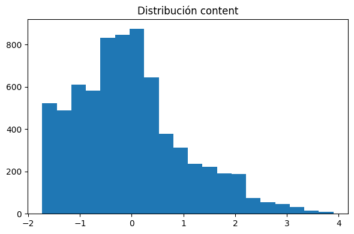

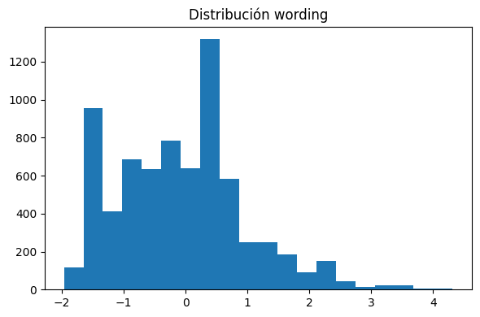

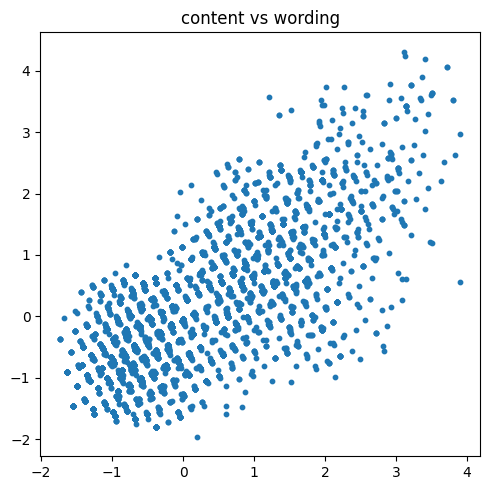

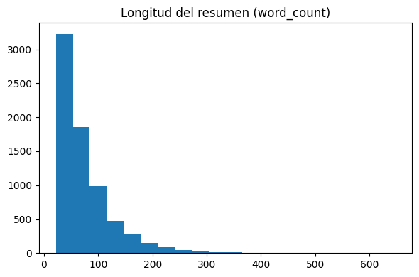

```python
# EDA básico
import numpy as np
import matplotlib.pyplot as plt

print("Filas:", len(df), "| Prompts únicos:", df['prompt_id'].nunique())
print("\nMissing values:\n", df.isnull().sum())

df['text_proc'] = df['text'].fillna("").astype(str).str.lower()
df['char_count'] = df['text_proc'].str.len().astype(float)
df['word_count'] = df['text_proc'].str.split().apply(len).astype(float)
df['avg_word_len'] = df['text_proc'].apply(lambda s: (np.mean([len(w) for w in s.split()]) if len(s.split())>0 else 0.0)).astype(float)
df['unique_word_ratio'] = df['text_proc'].apply(lambda s: (len(set(s.split()))/(len(s.split())+1e-9) if isinstance(s,str) else 0.0)).astype(float)

plt.figure(figsize=(6,4)); plt.hist(df['content'].dropna().values, bins=20); plt.title("Distribución content"); plt.tight_layout(); plt.show()
plt.figure(figsize=(6,4)); plt.hist(df['wording'].dropna().values, bins=20); plt.title("Distribución wording"); plt.tight_layout(); plt.show()
plt.figure(figsize=(5,5)); plt.scatter(df['content'].values, df['wording'].values, s=10); plt.title("content vs wording"); plt.tight_layout(); plt.show()
plt.figure(figsize=(6,4)); plt.hist(df['word_count'].dropna().values, bins=20); plt.title("Longitud del resumen (word_count)"); plt.tight_layout(); plt.show()
```

## Algoritmos de aprendizaje de máquinas a usar y justificación

- **Ridge (L2)**: baseline lineal robusto en alta dimensión (TF–IDF+SVD), controla sobreajuste y funciona bien con relaciones aproximadamente lineales.
- **RandomForest Regressor**: captura **no linealidades** e interacciones entre componentes latentes y rasgos numéricos sin requerir escalado.
- **LinearSVR**: optimiza un margen ε-insensible; con representaciones densas (SVD) puede generalizar mejor en presencia de *outliers* moderados.

**Representación**: TF–IDF con n-gramas (1–2) + SVD (LSA) para compactar a componentes densos; se agregan rasgos simples (longitud, vocabulario único, etc.).  
**Validación**: **GroupKFold por `prompt_id`** para evaluar generalización a *prompts* no vistos.

```python
# Features: TF-IDF + SVD + num features
from sklearn.feature_extraction.text import TfidfVectorizer
from sklearn.decomposition import TruncatedSVD
import numpy as np

df['prompt_all'] = (df['prompt_title'].fillna('') + ' ' + df['prompt_text'].fillna('') + ' ' + df['prompt_question'].fillna('')).str.strip()
df['text_all'] = (df['text_proc'] + ' ' + df['prompt_all'].str.lower()).str.strip()

tfidf = TfidfVectorizer(max_features=30000, ngram_range=(1,2), min_df=2)
X_tfidf = tfidf.fit_transform(df['text_all'].tolist())
svd = TruncatedSVD(n_components=150, random_state=42)
X_svd = svd.fit_transform(X_tfidf)

num_feats = ['char_count','word_count','unique_word_ratio','avg_word_len']
X_num = df[num_feats].to_numpy(dtype=float)

X = np.hstack([X_svd, X_num])
y = df[['content','wording']].to_numpy(dtype=float)
groups = df['prompt_id'].to_numpy()
X.shape, y.shape
```

```
((7165, 154), (7165, 2))
```

```python
# Modelos y validación GroupKFold
from sklearn.model_selection import GroupKFold
from sklearn.multioutput import MultiOutputRegressor
from sklearn.linear_model import Ridge
from sklearn.svm import LinearSVR
from sklearn.ensemble import RandomForestRegressor
from sklearn.metrics import mean_squared_error
import pandas as pd
import numpy as np
import matplotlib.pyplot as plt

def evaluate_models_group_rmse(X, y, groups, models, n_splits=4):
    gkf = GroupKFold(n_splits=n_splits)
    results = []
    oof_by_model = {}
    for mname, reg in models.items():
        rmse_all, rmse_c, rmse_w = [], [], []
        oof_pred = np.zeros_like(y)
        for fold, (tr_idx, va_idx) in enumerate(gkf.split(X, y, groups)):
            X_tr, X_va = X[tr_idx], X[va_idx]
            y_tr, y_va = y[tr_idx], y[va_idx]
            reg.fit(X_tr, y_tr)
            y_hat = reg.predict(X_va)
            oof_pred[va_idx] = y_hat
            rmse_c.append(mean_squared_error(y_va[:,0], y_hat[:,0], squared=False))
            rmse_w.append(mean_squared_error(y_va[:,1], y_hat[:,1], squared=False))
            rmse_all.append(mean_squared_error(y_va, y_hat, squared=False))
        results.append({
            "model": mname,
            "rmse_mean": float(np.mean(rmse_all)),
            "rmse_std": float(np.std(rmse_all)),
            "rmse_content": float(np.mean(rmse_c)),
            "rmse_wording": float(np.mean(rmse_w)),
            "splits": n_splits
        })
        oof_by_model[mname] = oof_pred
    res_df = pd.DataFrame(results).sort_values("rmse_mean").reset_index(drop=True)
    return res_df, oof_by_model

models = {
    "Ridge (L2)": MultiOutputRegressor(Ridge(alpha=1.0, random_state=42)),
    "RandomForest": RandomForestRegressor(n_estimators=350, max_depth=None, random_state=42, n_jobs=-1),
    "LinearSVR": MultiOutputRegressor(LinearSVR(epsilon=0.1, C=1.0, random_state=42)),
}

results_df, oof_by_model = evaluate_models_group_rmse(X, y, groups, models, n_splits=4)
results_df
```

[output not shown]

|  | model | rmse_mean | rmse_std | rmse_content | rmse_wording | splits |
| --- | --- | --- | --- | --- | --- | --- |
| 0 | RandomForest | 0.667631 | 0.034983 | 0.531144 | 0.780216 | 4 |
| 1 | LinearSVR | 1.282311 | 0.307470 | 0.877683 | 1.559893 | 4 |
| 2 | Ridge (L2) | 3.009435 | 0.240622 | 1.705431 | 3.893754 | 4 |

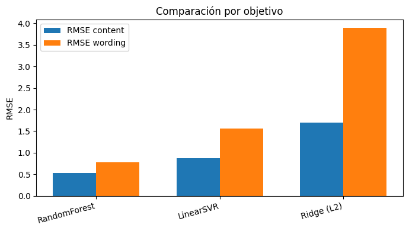

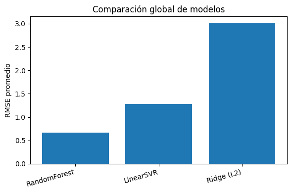

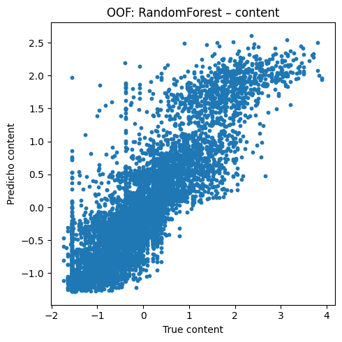

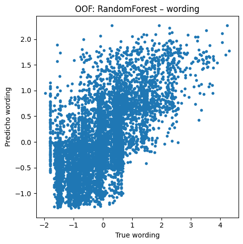

```python
# Visualizaciones comparativas
import numpy as np
import matplotlib.pyplot as plt

plt.figure(figsize=(7,4))
x = np.arange(len(results_df)); bw = 0.35
plt.bar(x - bw/2, results_df['rmse_content'].values, width=bw, label='RMSE content')
plt.bar(x + bw/2, results_df['rmse_wording'].values, width=bw, label='RMSE wording')
plt.xticks(x, results_df['model'].tolist(), rotation=15, ha='right')
plt.ylabel('RMSE'); plt.title('Comparación por objetivo')
plt.legend(); plt.tight_layout(); plt.show()

plt.figure(figsize=(6,4))
plt.bar(np.arange(len(results_df)), results_df['rmse_mean'].values)
plt.xticks(np.arange(len(results_df)), results_df['model'].tolist(), rotation=15, ha='right')
plt.ylabel('RMSE promedio'); plt.title('Comparación global de modelos')
plt.tight_layout(); plt.show()

best_name = results_df.iloc[0]['model']
best_oof = oof_by_model[best_name]

plt.figure(figsize=(5,5))
plt.scatter(y[:,0], best_oof[:,0], s=10)
plt.xlabel("True content"); plt.ylabel("Predicho content")
plt.title(f"OOF: {best_name} – content")
plt.tight_layout(); plt.show()

plt.figure(figsize=(5,5))
plt.scatter(y[:,1], best_oof[:,1], s=10)
plt.xlabel("True wording"); plt.ylabel("Predicho wording")
plt.title(f"OOF: {best_name} – wording")
plt.tight_layout(); plt.show()
```

# Chequeo de Sobreajuste para mejor modelo — Random Forest

Esta sección evalúa **sobreajuste** del modelo **RandomForestRegressor** usando:

1. **Brecha Train vs Validación** con **GroupKFold** por `prompt_id`.
2. **OOB (Out-Of-Bag)** del bosque.
3. **Curva de complejidad** (`max_depth`, `min_samples_leaf`).
4. **Gráficos de paridad y residuales** con OOF.

```python
# === Helpers de métricas y preparación segura ===
import numpy as np
import pandas as pd
from pathlib import Path
from sklearn.metrics import mean_squared_error
from sklearn.model_selection import GroupKFold
from sklearn.ensemble import RandomForestRegressor
import matplotlib.pyplot as plt

def rmse_(y_true, y_pred):
    try:
        return mean_squared_error(y_true, y_pred, squared=False)
    except TypeError:
        return np.sqrt(mean_squared_error(y_true, y_pred))

def ensure_X_y_groups(df=None, X=None, y=None, groups=None, data_dir=Path('.')):
    """
    Devuelve X, y, groups. Si no existen en el entorno, los reconstruye a partir de df o CSVs.
    Representación: TF-IDF(1-2) + SVD(150) + rasgos simples.
    """
    if X is not None and y is not None and groups is not None:
        return X, y, groups

    from sklearn.feature_extraction.text import TfidfVectorizer
    from sklearn.decomposition import TruncatedSVD
    import pandas as pd
    import numpy as np

    if df is None:
        sums_fp = data_dir / 'summaries_train.csv'
        pro_fp = data_dir / 'prompts_train.csv'
        summaries = pd.read_csv(sums_fp)
        prompts = pd.read_csv(pro_fp)
        df = summaries.merge(prompts, on='prompt_id', how='left')

    df = df.copy()
    df['text_proc'] = df['text'].fillna('').astype(str).str.lower()
    df['prompt_all'] = (df['prompt_title'].fillna('') + ' ' + df['prompt_text'].fillna('') + ' ' + df['prompt_question'].fillna('')).str.strip()
    df['text_all'] = (df['text_proc'] + ' ' + df['prompt_all'].str.lower()).str.strip()
    df['char_count'] = df['text_proc'].str.len().astype(float)
    df['word_count'] = df['text_proc'].str.split().apply(len).astype(float)
    df['avg_word_len'] = df['text_proc'].apply(lambda s: (np.mean([len(w) for w in s.split()]) if len(s.split())>0 else 0.0)).astype(float)
    df['unique_word_ratio'] = df['text_proc'].apply(lambda s: (len(set(s.split()))/(len(s.split())+1e-9) if isinstance(s,str) else 0.0)).astype(float)

    tfidf = TfidfVectorizer(max_features=30000, ngram_range=(1,2), min_df=2)
    X_tfidf = tfidf.fit_transform(df['text_all'].tolist())
    svd = TruncatedSVD(n_components=150, random_state=42)
    X_svd = svd.fit_transform(X_tfidf)

    num_feats = ['char_count','word_count','unique_word_ratio','avg_word_len']
    X_num = df[num_feats].to_numpy(dtype=float)
    X_ = np.hstack([X_svd, X_num])
    y_ = df[['content','wording']].to_numpy(dtype=float)
    groups_ = df['prompt_id'].to_numpy()
    return X_, y_, groups_
```

```python
# === 1) Brecha Train vs Validación (GroupKFold por prompt_id) ===
def rf_train_vs_cv_gap(X, y, groups, rf_kwargs=None, n_splits=4):
    if rf_kwargs is None:
        rf_kwargs = dict(
            n_estimators=300,
            random_state=42,
            n_jobs=-1,
            bootstrap=True,
            max_depth=None,
            min_samples_leaf=1,
            max_features='sqrt'
        )
    gkf = GroupKFold(n_splits=n_splits)
    train_rmse_c, val_rmse_c = [], []
    train_rmse_w, val_rmse_w = [], []

    for tr_idx, va_idx in gkf.split(X, y, groups):
        X_tr, X_va = X[tr_idx], X[va_idx]
        y_tr, y_va = y[tr_idx], y[va_idx]

        rf = RandomForestRegressor(**rf_kwargs)
        rf.fit(X_tr, y_tr)

        y_hat_tr = rf.predict(X_tr)
        y_hat_va = rf.predict(X_va)

        train_rmse_c.append(rmse_(y_tr[:,0], y_hat_tr[:,0]))
        val_rmse_c.append(rmse_(y_va[:,0], y_hat_va[:,0]))
        train_rmse_w.append(rmse_(y_tr[:,1], y_hat_tr[:,1]))
        val_rmse_w.append(rmse_(y_va[:,1], y_hat_va[:,1]))

    results = pd.DataFrame({
        'fold': np.arange(1, n_splits+1),
        'train_rmse_content': train_rmse_c,
        'valid_rmse_content': val_rmse_c,
        'train_rmse_wording': train_rmse_w,
        'valid_rmse_wording': val_rmse_w,
    })
    return results

# Preparar X, y, groups si no existen ya en el entorno
try:
    X, y, groups = ensure_X_y_groups(df=globals().get('df'), X=globals().get('X'), y=globals().get('y'), groups=globals().get('groups'))
except Exception as e:
    print('No fue posible preparar X, y, groups automáticamente:', e)
    raise

gap_df = rf_train_vs_cv_gap(X, y, groups, n_splits=4)
gap_df
```

|  | fold | train_rmse_content | valid_rmse_content | train_rmse_wording | valid_rmse_wording |
| --- | --- | --- | --- | --- | --- |
| 0 | 1 | 0.180769 | 0.569391 | 0.237193 | 0.877170 |
| 1 | 2 | 0.170246 | 0.676308 | 0.224520 | 0.789053 |
| 2 | 3 | 0.177589 | 0.575224 | 0.239703 | 0.745840 |
| 3 | 4 | 0.170568 | 0.652882 | 0.226524 | 0.889142 |

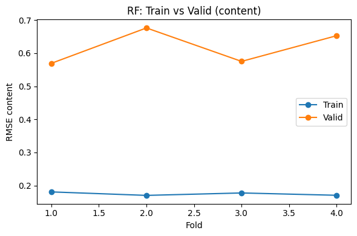

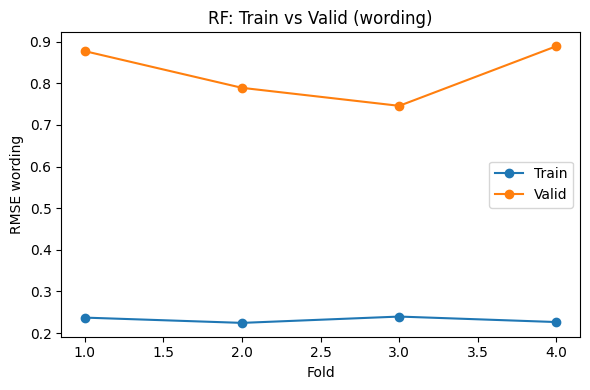

```python
# Gráficas: Train vs Validación por fold
plt.figure(figsize=(6,4))
plt.plot(gap_df['fold'], gap_df['train_rmse_content'], marker='o', label='Train')
plt.plot(gap_df['fold'], gap_df['valid_rmse_content'], marker='o', label='Valid')
plt.xlabel('Fold'); plt.ylabel('RMSE content'); plt.title('RF: Train vs Valid (content)')
plt.legend(); plt.tight_layout(); plt.show()

plt.figure(figsize=(6,4))
plt.plot(gap_df['fold'], gap_df['train_rmse_wording'], marker='o', label='Train')
plt.plot(gap_df['fold'], gap_df['valid_rmse_wording'], marker='o', label='Valid')
plt.xlabel('Fold'); plt.ylabel('RMSE wording'); plt.title('RF: Train vs Valid (wording)')
plt.legend(); plt.tight_layout(); plt.show()
```

```python
# === 2) OOB (Out-Of-Bag) ===
rf_oob = RandomForestRegressor(
    n_estimators=500, random_state=42, n_jobs=-1,
    bootstrap=True, oob_score=True, max_features='sqrt'
)
rf_oob.fit(X, y)

oob_r2 = getattr(rf_oob, 'oob_score_', None)
print('OOB R2 (promedio de salidas):', oob_r2)

if hasattr(rf_oob, 'oob_prediction_'):
    oob_pred = rf_oob.oob_prediction_
    print('OOB RMSE content:', rmse_(y[:,0], oob_pred[:,0]))
    print('OOB RMSE wording:', rmse_(y[:,1], oob_pred[:,1]))
```

```
OOB R2 (promedio de salidas): 0.7137541821291379
OOB RMSE content: 0.47131413682478174
OOB RMSE wording: 0.6288702202272511
```

```python
# === 3) Curva de complejidad: barrer max_depth y min_samples_leaf ===
def grid_depth_minleaf(X, y, groups, depths=(None, 24, 16, 10, 6), leaves=(1, 2, 5)):
    rows = []
    for md in depths:
        for mleaf in leaves:
            res = rf_train_vs_cv_gap(X, y, groups, rf_kwargs=dict(
                n_estimators=300, random_state=42, n_jobs=-1,
                bootstrap=True, max_depth=md, min_samples_leaf=mleaf, max_features='sqrt'
            ), n_splits=4)
            rows.append({
                'max_depth': md, 'min_samples_leaf': mleaf,
                'train_c': res['train_rmse_content'].mean(),
                'valid_c': res['valid_rmse_content'].mean(),
                'train_w': res['train_rmse_wording'].mean(),
                'valid_w': res['valid_rmse_wording'].mean(),
            })
    return pd.DataFrame(rows).sort_values(['valid_c','valid_w']).reset_index(drop=True)

grid_df = grid_depth_minleaf(X, y, groups)
grid_df.head(10)
```

|  | max_depth | min_samples_leaf | train_c | valid_c | train_w | valid_w |
| --- | --- | --- | --- | --- | --- | --- |
| 0 | 16.0 | 2 | 0.249269 | 0.611894 | 0.312337 | 0.828783 |
| 1 | 24.0 | 1 | 0.175461 | 0.617223 | 0.232943 | 0.823854 |
| 2 | NaN | 2 | 0.227692 | 0.617478 | 0.286826 | 0.828554 |
| 3 | 24.0 | 2 | 0.228169 | 0.617971 | 0.286975 | 0.831707 |
| 4 | NaN | 1 | 0.174793 | 0.618451 | 0.231985 | 0.825302 |
| 5 | 16.0 | 1 | 0.211874 | 0.619696 | 0.273191 | 0.830322 |
| 6 | 16.0 | 5 | 0.336077 | 0.620725 | 0.420654 | 0.828713 |
| 7 | 24.0 | 5 | 0.330419 | 0.621898 | 0.413360 | 0.829866 |
| 8 | NaN | 5 | 0.330428 | 0.622902 | 0.413369 | 0.829622 |
| 9 | 10.0 | 2 | 0.372203 | 0.628178 | 0.478103 | 0.834453 |

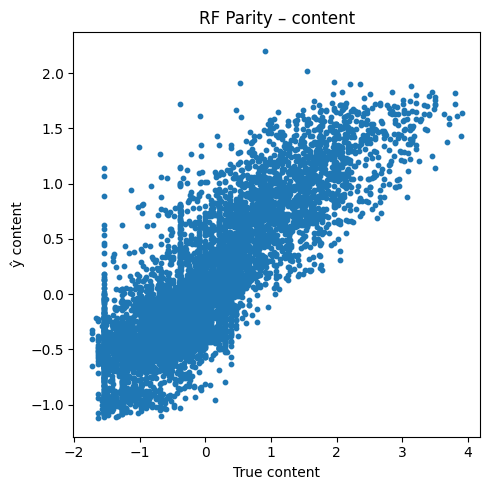

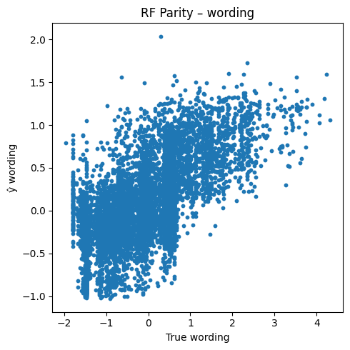

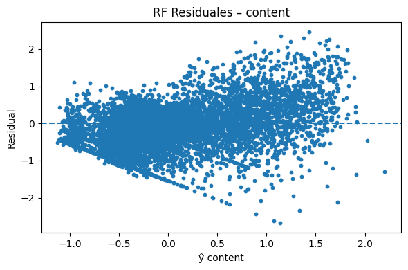

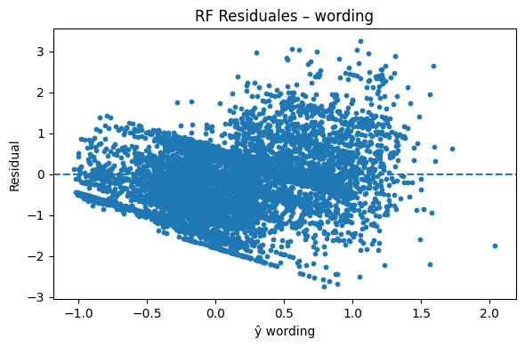

```python
# === 4) Paridad y residuales (OOF por GroupKFold) ===
gkf = GroupKFold(n_splits=4)
oof = np.zeros_like(y)

for tr_idx, va_idx in gkf.split(X, y, groups):
    rf = RandomForestRegressor(n_estimators=400, random_state=42, n_jobs=-1, bootstrap=True, max_features='sqrt')
    rf.fit(X[tr_idx], y[tr_idx])
    oof[va_idx] = rf.predict(X[va_idx])

plt.figure(figsize=(5,5))
plt.scatter(y[:,0], oof[:,0], s=10)
plt.xlabel('True content'); plt.ylabel('ŷ content'); plt.title('RF Parity – content')
plt.tight_layout(); plt.show()

plt.figure(figsize=(5,5))
plt.scatter(y[:,1], oof[:,1], s=10)
plt.xlabel('True wording'); plt.ylabel('ŷ wording'); plt.title('RF Parity – wording')
plt.tight_layout(); plt.show()

res_c = y[:,0] - oof[:,0]
res_w = y[:,1] - oof[:,1]

plt.figure(figsize=(6,4))
plt.scatter(oof[:,0], res_c, s=10); plt.axhline(0, ls='--')
plt.xlabel('ŷ content'); plt.ylabel('Residual'); plt.title('RF Residuales – content')
plt.tight_layout(); plt.show()

plt.figure(figsize=(6,4))
plt.scatter(oof[:,1], res_w, s=10); plt.axhline(0, ls='--')
plt.xlabel('ŷ wording'); plt.ylabel('Residual'); plt.title('RF Residuales – wording')
plt.tight_layout(); plt.show()
```

# Chequeo de Sobreajuste — LinearSVR

Evaluamos el **sobreajuste** del modelo **LinearSVR** (envuelto con `MultiOutputRegressor`) usando:

1. **Brecha Train vs Validación** con **GroupKFold** por `prompt_id`, con opción de **escalado** de `X` (recomendado para SVM).
2. **Curva de complejidad** variando `C` y `epsilon`.
3. **Gráficos de paridad (y vs ŷ) y residuales** con predicciones OOF (*out-of-fold*).

```python
# === Helpers para LinearSVR (y compatibilidad) ===
import numpy as np
import pandas as pd
import matplotlib.pyplot as plt
from pathlib import Path

from sklearn.svm import LinearSVR
from sklearn.multioutput import MultiOutputRegressor
from sklearn.metrics import mean_squared_error
from sklearn.model_selection import GroupKFold
from sklearn.preprocessing import StandardScaler

# Reusar rmse_ si existe; si no, definirlo
try:
    rmse_
except NameError:
    def rmse_(y_true, y_pred):
        try:
            return mean_squared_error(y_true, y_pred, squared=False)
        except TypeError:
            return np.sqrt(mean_squared_error(y_true, y_pred))

# Reusar ensure_X_y_groups si existe; si no, definirlo
try:
    ensure_X_y_groups
except NameError:
    from sklearn.feature_extraction.text import TfidfVectorizer
    from sklearn.decomposition import TruncatedSVD
    def ensure_X_y_groups(df=None, X=None, y=None, groups=None, data_dir=Path('.')):
        if X is not None and y is not None and groups is not None:
            return X, y, groups
        if df is None:
            sums_fp = data_dir / 'summaries_train.csv'
            pro_fp  = data_dir / 'prompts_train.csv'
            summaries = pd.read_csv(sums_fp)
            prompts   = pd.read_csv(pro_fp)
            df = summaries.merge(prompts, on='prompt_id', how='left')
        df = df.copy()
        df['text_proc'] = df['text'].fillna('').astype(str).str.lower()
        df['prompt_all'] = (df['prompt_title'].fillna('') + ' ' + df['prompt_text'].fillna('') + ' ' + df['prompt_question'].fillna('')).str.strip()
        df['text_all'] = (df['text_proc'] + ' ' + df['prompt_all'].str.lower()).str.strip()
        df['char_count'] = df['text_proc'].str.len().astype(float)
        df['word_count'] = df['text_proc'].str.split().apply(len).astype(float)
        df['avg_word_len'] = df['text_proc'].apply(lambda s: (np.mean([len(w) for w in s.split()]) if len(s.split())>0 else 0.0)).astype(float)
        df['unique_word_ratio'] = df['text_proc'].apply(lambda s: (len(set(s.split()))/(len(s.split())+1e-9) if isinstance(s,str) else 0.0)).astype(float)

        tfidf = TfidfVectorizer(max_features=30000, ngram_range=(1,2), min_df=2)
        X_tfidf = tfidf.fit_transform(df['text_all'].tolist())
        svd = TruncatedSVD(n_components=150, random_state=42)
        X_svd = svd.fit_transform(X_tfidf)

        num_feats = ['char_count','word_count','unique_word_ratio','avg_word_len']
        X_num = df[num_feats].to_numpy(dtype=float)
        X_ = np.hstack([X_svd, X_num])
        y_ = df[['content','wording']].to_numpy(dtype=float)
        groups_ = df['prompt_id'].to_numpy()
        return X_, y_, groups_
```

```python
# === 1) Brecha Train vs Validación (GroupKFold por prompt_id) con LinearSVR ===
def lsvr_train_vs_cv_gap(X, y, groups, lsvr_kwargs=None, n_splits=4, scale=True):
    if lsvr_kwargs is None:
        lsvr_kwargs = dict(C=1.0, epsilon=0.1, random_state=42)
    gkf = GroupKFold(n_splits=n_splits)
    train_rmse_c, val_rmse_c = [], []
    train_rmse_w, val_rmse_w = [], []

    for tr_idx, va_idx in gkf.split(X, y, groups):
        X_tr, X_va = X[tr_idx], X[va_idx]
        y_tr, y_va = y[tr_idx], y[va_idx]

        # Escalado recomendado para SVM lineal
        if scale:
            scaler = StandardScaler(with_mean=False) if X_tr.ndim == 2 else StandardScaler()
            # with_mean=False por si X proviene de matrices dispersas antes de SVD; aquí X es denso pero es seguro
            X_tr_s = scaler.fit_transform(X_tr)
            X_va_s = scaler.transform(X_va)
        else:
            X_tr_s, X_va_s = X_tr, X_va

        reg = MultiOutputRegressor(LinearSVR(**lsvr_kwargs))
        reg.fit(X_tr_s, y_tr)

        y_hat_tr = reg.predict(X_tr_s)
        y_hat_va = reg.predict(X_va_s)

        train_rmse_c.append(rmse_(y_tr[:,0], y_hat_tr[:,0]))
        val_rmse_c.append(rmse_(y_va[:,0], y_hat_va[:,0]))
        train_rmse_w.append(rmse_(y_tr[:,1], y_hat_tr[:,1]))
        val_rmse_w.append(rmse_(y_va[:,1], y_hat_va[:,1]))

    results = pd.DataFrame({
        'fold': np.arange(1, n_splits+1),
        'train_rmse_content': train_rmse_c,
        'valid_rmse_content': val_rmse_c,
        'train_rmse_wording': train_rmse_w,
        'valid_rmse_wording': val_rmse_w,
    })
    return results

# Preparar X, y, groups (reusa del entorno o reconstruye)
try:
    X, y, groups = ensure_X_y_groups(df=globals().get('df'), X=globals().get('X'), y=globals().get('y'), groups=globals().get('groups'))
except Exception as e:
    print('No fue posible preparar X, y, groups automáticamente:', e)
    raise

lsvr_gap_df = lsvr_train_vs_cv_gap(X, y, groups, n_splits=4, scale=True)
lsvr_gap_df
```

[output not shown]

|  | fold | train_rmse_content | valid_rmse_content | train_rmse_wording | valid_rmse_wording |
| --- | --- | --- | --- | --- | --- |
| 0 | 1 | 0.615930 | 5.422681 | 0.675461 | 18.564348 |
| 1 | 2 | 0.524904 | 2.623985 | 0.615986 | 4.166058 |
| 2 | 3 | 0.534593 | 2.622642 | 0.673860 | 8.118967 |
| 3 | 4 | 0.533016 | 9.004322 | 0.619273 | 28.506214 |

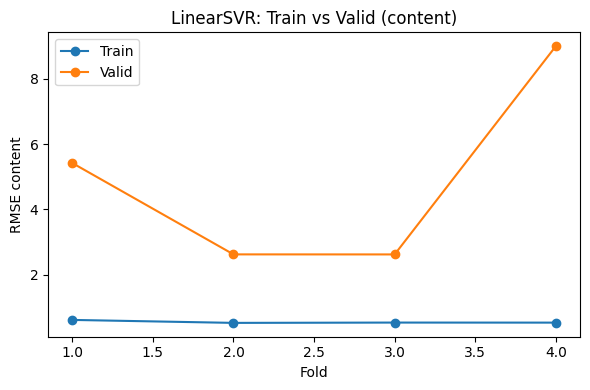

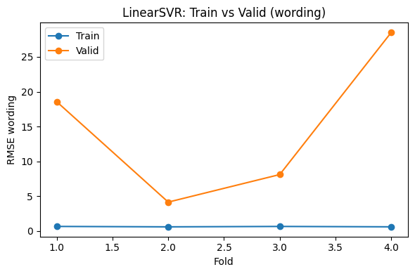

```python
# Gráficas: Train vs Validación (LinearSVR) por fold
plt.figure(figsize=(6,4))
plt.plot(lsvr_gap_df['fold'], lsvr_gap_df['train_rmse_content'], marker='o', label='Train')
plt.plot(lsvr_gap_df['fold'], lsvr_gap_df['valid_rmse_content'], marker='o', label='Valid')
plt.xlabel('Fold'); plt.ylabel('RMSE content'); plt.title('LinearSVR: Train vs Valid (content)')
plt.legend(); plt.tight_layout(); plt.show()

plt.figure(figsize=(6,4))
plt.plot(lsvr_gap_df['fold'], lsvr_gap_df['train_rmse_wording'], marker='o', label='Train')
plt.plot(lsvr_gap_df['fold'], lsvr_gap_df['valid_rmse_wording'], marker='o', label='Valid')
plt.xlabel('Fold'); plt.ylabel('RMSE wording'); plt.title('LinearSVR: Train vs Valid (wording)')
plt.legend(); plt.tight_layout(); plt.show()
```

```python
# === 2) Curva de complejidad: barrer C y epsilon (LinearSVR) ===
def grid_C_epsilon(X, y, groups, C_list=(0.1, 0.5, 1.0, 3.0, 10.0), eps_list=(0.05, 0.1, 0.2, 0.3), n_splits=4, scale=True):
    rows = []
    for C in C_list:
        for eps in eps_list:
            res = lsvr_train_vs_cv_gap(X, y, groups, lsvr_kwargs=dict(C=C, epsilon=eps, random_state=42), n_splits=n_splits, scale=scale)
            rows.append({
                'C': C, 'epsilon': eps,
                'train_c': res['train_rmse_content'].mean(),
                'valid_c': res['valid_rmse_content'].mean(),
                'train_w': res['train_rmse_wording'].mean(),
                'valid_w': res['valid_rmse_wording'].mean(),
                'gap_c': res['valid_rmse_content'].mean() - res['train_rmse_content'].mean(),
                'gap_w': res['valid_rmse_wording'].mean() - res['train_rmse_wording'].mean(),
            })
    grid = pd.DataFrame(rows).sort_values(['valid_c','valid_w']).reset_index(drop=True)
    return grid

lsvr_grid_df = grid_C_epsilon(X, y, groups, n_splits=4, scale=True)
lsvr_grid_df.head(10)
```

[output not shown]

[output cut: 265 more lines]

[output not shown]

|  | C | epsilon | train_c | valid_c | train_w | valid_w | gap_c | gap_w |
| --- | --- | --- | --- | --- | --- | --- | --- | --- |
| 0 | 0.1 | 0.20 | 0.503233 | 2.699457 | 0.628893 | 7.488345 | 2.196225 | 6.859452 |
| 1 | 0.1 | 0.30 | 0.500728 | 2.877340 | 0.627154 | 7.662670 | 2.376611 | 7.035516 |
| 2 | 0.1 | 0.10 | 0.504723 | 3.137384 | 0.630871 | 7.709773 | 2.632661 | 7.078902 |
| 3 | 0.1 | 0.05 | 0.506367 | 3.221907 | 0.631218 | 7.800010 | 2.715540 | 7.168792 |
| 4 | 0.5 | 0.05 | 0.526031 | 3.690250 | 0.642283 | 12.836781 | 3.164219 | 12.194498 |
| 5 | 0.5 | 0.20 | 0.508520 | 3.748809 | 0.637106 | 10.945774 | 3.240289 | 10.308668 |
| 6 | 0.5 | 0.10 | 0.512293 | 3.867339 | 0.660832 | 12.711696 | 3.355046 | 12.050865 |
| 7 | 0.5 | 0.30 | 0.514648 | 3.971712 | 0.634132 | 11.415201 | 3.457064 | 10.781069 |
| 8 | 1.0 | 0.05 | 0.520309 | 4.805934 | 0.650950 | 14.171551 | 4.285625 | 13.520601 |
| 9 | 1.0 | 0.10 | 0.552111 | 4.918407 | 0.646145 | 14.838896 | 4.366297 | 14.192751 |

[output not shown]

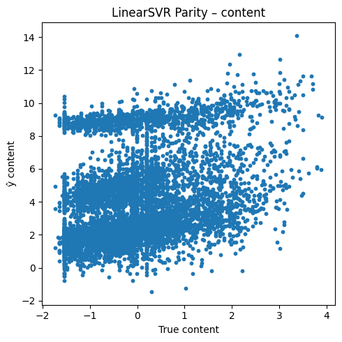

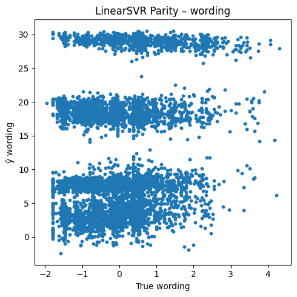

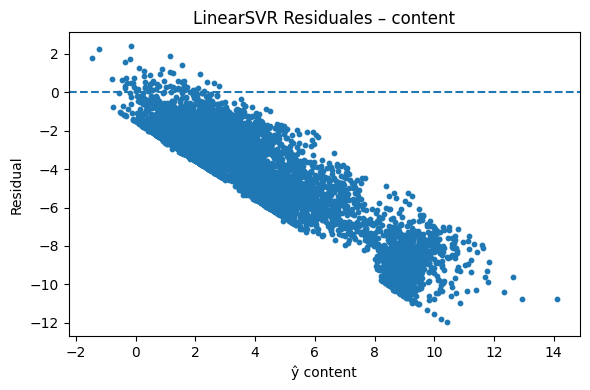

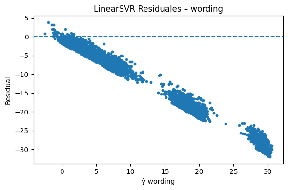

```python
# === 3) Paridad y residuales con OOF (LinearSVR) ===
gkf = GroupKFold(n_splits=4)
oof = np.zeros_like(y)

for tr_idx, va_idx in gkf.split(X, y, groups):
    scaler = StandardScaler(with_mean=False)
    X_tr_s = scaler.fit_transform(X[tr_idx])
    X_va_s = scaler.transform(X[va_idx])

    reg = MultiOutputRegressor(LinearSVR(C=1.0, epsilon=0.1, random_state=42))
    reg.fit(X_tr_s, y[tr_idx])
    oof[va_idx] = reg.predict(X_va_s)

# Parity plots
plt.figure(figsize=(5,5))
plt.scatter(y[:,0], oof[:,0], s=10)
plt.xlabel('True content'); plt.ylabel('ŷ content'); plt.title('LinearSVR Parity – content')
plt.tight_layout(); plt.show()

plt.figure(figsize=(5,5))
plt.scatter(y[:,1], oof[:,1], s=10)
plt.xlabel('True wording'); plt.ylabel('ŷ wording'); plt.title('LinearSVR Parity – wording')
plt.tight_layout(); plt.show()

# Residuales
res_c = y[:,0] - oof[:,0]
res_w = y[:,1] - oof[:,1]

plt.figure(figsize=(6,4))
plt.scatter(oof[:,0], res_c, s=10); plt.axhline(0, ls='--')
plt.xlabel('ŷ content'); plt.ylabel('Residual'); plt.title('LinearSVR Residuales – content')
plt.tight_layout(); plt.show()

plt.figure(figsize=(6,4))
plt.scatter(oof[:,1], res_w, s=10); plt.axhline(0, ls='--')
plt.xlabel('ŷ wording'); plt.ylabel('Residual'); plt.title('LinearSVR Residuales – wording')
plt.tight_layout(); plt.show()
```

## Bibliografia

Cortes, C., Mohri, M., & Rostamizadeh, A. (2012). L2 Regularization for Learning Kernels. arXiv (Cornell University). https://doi.org/10.48550/arxiv.1205.2653

García-Floriano, A., López-Martín, C., Yáñez-Márquez, C., & Abran, A. (2018). Support vector regression for predicting software enhancement effort. Information And Software Technology, 97, 99-109. https://doi.org/10.1016/j.infsof.2018.01.003

Hastie, T. (2020). Ridge Regularization: An Essential Concept in Data Science. Technometrics, 62(4), 426-433. https://doi.org/10.1080/00401706.2020.1791959

Mahesh, B. (2020). Machine Learning Algorithms - a review. International Journal Of Science And Research (IJSR), 9(1), 381-386. https://doi.org/10.21275/art20203995

R, P., G, D., T, R. K., & B, S. P. (2021). Study on machine learning algorithms. International Journal Of Scientific Research In Computer Science Engineering And Information Technology, 67-72. https://doi.org/10.32628/cseit2173105

Salman, H. A., Kalakech, A., & Steiti, A. (2024). Random Forest Algorithm Overview. Deleted Journal, 2024, 69-79. https://doi.org/10.58496/bjml/2024/007